# Geospatial Analysis of Dry Season Environmnetal Drivers of Malaria Cases in Kasungu

# 8 Model evaluation

Here, we evaluate how well the `Poisson regression` model is predicting the outcome of a new test data that have not been used to build the model i.e how close the prediction is close to the real value.

## 8.1 Scatter plot of fitted vs obeserved values

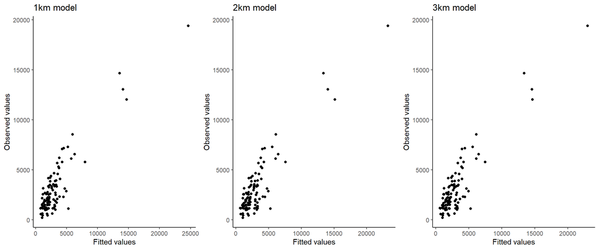

Fig. 3. How well the percentage of catchment population living around water bodies explain observed malaria incidence

```r
# Helper function to create scatter plots to see how well
# fitted values line up with observed malaria cases
plot.fitted.values <- function(fitted.values.df, model.df, title){

  # Remove missing values from model data since
  # model fitting deletes missing observations
  model.df.complete <- model.df |>
    tidyr::drop_na() |>
    dplyr::rename_at(vars(starts_with("observed_")), ~ str_c("observed"))

  # Plot fitted versus observed values
  scatter.plot <- ggplot2::ggplot()+
                  ggplot2::geom_point(aes(fitted.values.df$fitted.values,
                                          model.df.complete$observed))+
                  ggplot2::theme_classic()+
                  ggplot2::labs(x = "Fitted values",
                                y = "Observed values",
                                title = title)
  return(scatter.plot)
}

# Invoking function ------------------------------------------------------------
scatter_plot_1km <- plot.fitted.values(multivariate_1km, model_data, title = "1km model")

scatter_plot_2km <- plot.fitted.values(multivariate_2km, model_data, title = "2km model")

scatter_plot_3km <- plot.fitted.values(multivariate_3km, model_data, title = "3km model")

# Layout scatter plots ---------------------------------------------------------
cowplot::plot_grid(scatter_plot_1km, scatter_plot_2km, scatter_plot_3km, ncol = 3)
```

## 8.2 Estimate prediction error

Since our dataset is small and partitioning it will lead to higher bias, therefore, we use the `Leave one out cross validation` (`LOOCV`) method which uses all data points to measure performance of the `Poisson model`. This method works as follow:

1. Split a dataset into a training set and a testing set, using all but one observation as part of the training set.
2. Build a model using only data from the training set.
3. Use the model to predict the response value of the one observation left out of the model and calculate the `root mean squared error` (`RMSE`).
4. Repeat this process *n* times. Calculate the test `RMSE` to be the average of all of the test `RMSE`’s.

`RMSE`: The `Root Mean Squared Error`, which measures the model prediction error. It corresponds to the average difference between the observed known values of the outcome and the predicted value by the model.`RMSE` is computed as `RMSE = mean((observed - predicted)^2) |> sqrt()`. The lower the `RMSE`, the more closely a model can predict the actual observations. That is, the closer the model predictions are to the observations, the smaller the `RMSE` will be. Thus, the lower the `RMSE`, the better the model.

$$RMSE = \sqrt \frac {\Sigma ( y - \hat{y} )^2}{N}$$
`Rsquared`: This is a measure of the correlation between the predictions made by the model and the actual observations. The higher the `R-squared`, the more closely a model can predict the actual observations.

`MAE`: The mean absolute error. This is the average absolute difference between the predictions made by the model and the actual observations. The lower the `MAE`, the more closely a model can predict the actual observations.

*Gareth. J, Witten. D, Hastie. T, and Tibshirani. R. 2014. An Introduction to Statistical Learning: With Applications in R. Springer Publishing Company, Incorporated.*

```r
# Define training control
train_control <-  caret::trainControl(method = "LOOCV")

# Train the model, fit a regression model and use LOOCV to evaluate perfomance
train_multivariate_model_1km <- caret::train(
  observed_cases~1+prop_pop_1km+year+offset(log(expected_cases)),
  data = model_data, method = "glm",
  trControl = train_control, family = "poisson")

train_multivariate_model_2km <- caret::train(
  observed_cases~1+prop_pop_2km+year+offset(log(expected_cases)),
  data = model_data, method = "glm",
  trControl = train_control, family = "poisson")


train_multivariate_model_3km <- caret::train(
  observed_cases~1+prop_pop_3km+year+offset(log(expected_cases)),
  data = model_data, method = "glm",
  trControl = train_control, family = "poisson")

# Summarize the results
# The lower the RMSE and MAE the more closely a model can predict the actual observations
print(train_multivariate_model_1km)
```

```
## Generalized Linear Model
##
## 104 samples
##   3 predictor
##
## No pre-processing
## Resampling: Leave-One-Out Cross-Validation
## Summary of sample sizes: 103, 103, 103, 103, 103, 103, ...
## Resampling results:
##
##   RMSE      Rsquared    MAE
##   2854.871  0.07951775  1774.594
```

```r
print(train_multivariate_model_2km)
```

```
## Generalized Linear Model
##
## 104 samples
##   3 predictor
##
## No pre-processing
## Resampling: Leave-One-Out Cross-Validation
## Summary of sample sizes: 103, 103, 103, 103, 103, 103, ...
## Resampling results:
##
##   RMSE      Rsquared    MAE
##   2856.232  0.07214356  1761.653
```

```r
print(train_multivariate_model_3km)
```

```
## Generalized Linear Model
##
## 104 samples
##   3 predictor
##
## No pre-processing
## Resampling: Leave-One-Out Cross-Validation
## Summary of sample sizes: 103, 103, 103, 103, 103, 103, ...
## Resampling results:
##
##   RMSE      Rsquared    MAE
##   2843.925  0.07537095  1746.04
```

Here is how to interpret the output:

104 different samples were used to build 104 models. Each model used 3 predictor variables.

No pre-processing occured. That is, we didn’t scale the data in any way before fitting the models.

The sample size for each training set was 103.